# Final Project: Predicting IMDb Ratings for Scooby-Doo Movies

I will work with Scooby Doo Data from tidy tuesday. I want to analise the influence of different predictors to the movies’ imdb ratings. My hypothesis: The simple model, which includes the year when the cartoon was aired and the network producing the cartoon as predictors, will have less predictive power compared to the complex model, which incorporates additional predictors such as the number of suspects, culprits, and monsters. #Get the Data

```r
scoobydoo <- read.csv('https://raw.githubusercontent.com/rfordatascience/tidytuesday/main/data/2021/2021-07-13/scoobydoo.csv', stringsAsFactors = FALSE)
```

```r
#I select Scooby Doo movies
summary(is.na(scoobydoo))
```

```
##    index         series_name      network          season
##  Mode :logical   Mode :logical   Mode :logical   Mode :logical
##  FALSE:603       FALSE:603       FALSE:603       FALSE:603
##
##    title            imdb         engagement      date_aired
##  Mode :logical   Mode :logical   Mode :logical   Mode :logical
##  FALSE:603       FALSE:603       FALSE:603       FALSE:603
##
##   run_time         format        monster_name    monster_gender
##  Mode :logical   Mode :logical   Mode :logical   Mode :logical
##  FALSE:603       FALSE:603       FALSE:603       FALSE:603
##
##  monster_type    monster_subtype monster_species monster_real
##  Mode :logical   Mode :logical   Mode :logical   Mode :logical
##  FALSE:603       FALSE:603       FALSE:603       FALSE:603
##
##  monster_amount  caught_fred     caught_daphnie  caught_velma
##  Mode :logical   Mode :logical   Mode :logical   Mode :logical
##  FALSE:603       FALSE:603       FALSE:603       FALSE:603
##
##  caught_shaggy   caught_scooby   captured_fred   captured_daphnie
##  Mode :logical   Mode :logical   Mode :logical   Mode :logical
##  FALSE:603       FALSE:603       FALSE:603       FALSE:603
##
##  captured_velma  captured_shaggy captured_scooby unmask_fred
##  Mode :logical   Mode :logical   Mode :logical   Mode :logical
##  FALSE:603       FALSE:603       FALSE:603       FALSE:603
##
##  unmask_daphnie  unmask_velma    unmask_shaggy   unmask_scooby
##  Mode :logical   Mode :logical   Mode :logical   Mode :logical
##  FALSE:603       FALSE:603       FALSE:603       FALSE:603
##
##  snack_fred      snack_daphnie   snack_velma     snack_shaggy
##  Mode :logical   Mode :logical   Mode :logical   Mode :logical
##  FALSE:603       FALSE:603       FALSE:603       FALSE:603
##
##  snack_scooby    unmask_other    caught_other    caught_not
##  Mode :logical   Mode :logical   Mode :logical   Mode :logical
##  FALSE:603       FALSE:603       FALSE:603       FALSE:603
##
```

[output cut: 21 more lines]

```
##  Mode :logical         Mode :logical   Mode :logical   Mode :logical
##  FALSE:603             FALSE:603       FALSE:603       FALSE:603
##
##  rooby_rooby_roo   batman        scooby_dum      scrappy_doo
##  Mode :logical   Mode :logical   Mode :logical   Mode :logical
##  FALSE:603       FALSE:603       FALSE:603       FALSE:603
##
##  hex_girls       blue_falcon      fred_va        daphnie_va
##  Mode :logical   Mode :logical   Mode :logical   Mode :logical
##  FALSE:603       FALSE:603       FALSE:603       FALSE:603
##
##   velma_va       shaggy_va       scooby_va
##  Mode :logical   Mode :logical   Mode :logical
##  FALSE:603       FALSE:603       FALSE:603
##
```

```r
str(scoobydoo)
```

```
## 'data.frame':    603 obs. of  75 variables:
##  $ index                   : int  1 2 3 4 5 6 7 8 9 10 ...
##  $ series_name             : chr  "Scooby Doo, Where Are You!" "Scooby Doo, Where Are You!" "Scooby Doo, Where Are You!" "Scooby Doo, Where Are You!" ...
##  $ network                 : chr  "CBS" "CBS" "CBS" "CBS" ...
##  $ season                  : chr  "1" "1" "1" "1" ...
##  $ title                   : chr  "What a Night for a Knight" "A Clue for Scooby Doo" "Hassle in the Castle" "Mine Your Own Business" ...
##  $ imdb                    : chr  "8.1" "8.1" "8" "7.8" ...
##  $ engagement              : chr  "556" "479" "455" "426" ...
##  $ date_aired              : chr  "1969-09-13" "1969-09-20" "1969-09-27" "1969-10-04" ...
##  $ run_time                : int  21 22 21 21 21 21 21 21 21 21 ...
##  $ format                  : chr  "TV Series" "TV Series" "TV Series" "TV Series" ...
##  $ monster_name            : chr  "Black Knight" "Ghost of Cptn. Cuttler" "Phantom" "Miner 49'er" ...
##  $ monster_gender          : chr  "Male" "Male" "Male" "Male" ...
##  $ monster_type            : chr  "Possessed Object" "Ghost" "Ghost" "Ancient" ...
##  $ monster_subtype         : chr  "Suit" "Suit" "Phantom" "Miner" ...
```

[output cut: 61 more lines]

```r
scoobydoo_movies <- scoobydoo %>%
  filter(format == "Movie")
```

```r
#Selecting variables I want to work with: the imdb ratings, network and date when the cartoon is aired, monsters, culprits and suspects amount in each cartoon.The title is only important to be able to check something if needed.
scoobydoo_filtered <- scoobydoo_movies %>%
dplyr::select(imdb, network, title, date_aired, monster_amount, culprit_amount, suspects_amount, format)


# Only leave the year when the movie was aired: I want to use it in my model and the precise date is not important, since I want to see how imdb ratings changed over the years.

scoobydoo_filtered <- scoobydoo_filtered %>%
  mutate(date_aired = format(as.Date(date_aired, format = "%Y-%m-%d"), "%Y"))

scoobydoo_filtered <- scoobydoo_filtered %>%
  rename(year_aired = date_aired)
```

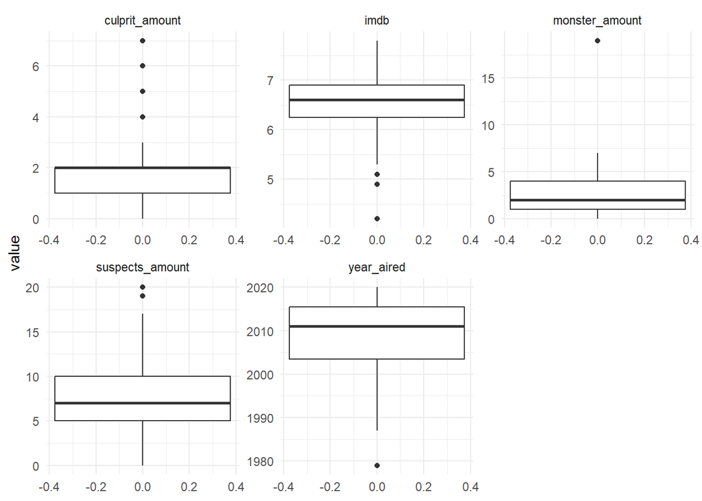

```r
# Convert numeric columns to numeric
scoobydoo_filtered <- scoobydoo_filtered %>%
  mutate(across(c(imdb, year_aired, monster_amount, culprit_amount, suspects_amount), as.numeric))

# Checking outliers for numeric variables. There are some outliers, but those are all not errors. For instance, there are really 19 monsters in one of the cartoons.

scoobydoo_filtered %>%
  pivot_longer(cols = where(is.numeric)) %>%
  ggplot(aes(x = value)) +
  geom_boxplot() +
  facet_wrap(~name, scales = "free") +

  coord_flip() +
  theme_minimal()
```

```r
summary(scoobydoo_filtered)
```

```
##       imdb         network             title             year_aired
##  Min.   :4.200   Length:43          Length:43          Min.   :1979
##  1st Qu.:6.250   Class :character   Class :character   1st Qu.:2004
##  Median :6.600   Mode  :character   Mode  :character   Median :2011
##  Mean   :6.467                                         Mean   :2008
##  3rd Qu.:6.900                                         3rd Qu.:2016
##  Max.   :7.800                                         Max.   :2020
##  monster_amount   culprit_amount suspects_amount     format
##  Min.   : 0.000   Min.   :0.00   Min.   : 0.000   Length:43
##  1st Qu.: 1.000   1st Qu.:1.00   1st Qu.: 5.000   Class :character
##  Median : 2.000   Median :2.00   Median : 7.000   Mode  :character
##  Mean   : 2.837   Mean   :1.93   Mean   : 8.116
##  3rd Qu.: 4.000   3rd Qu.:2.00   3rd Qu.:10.000
##  Max.   :19.000   Max.   :7.00   Max.   :20.000
```

```r
# Recode 'network' into "Warner Home Video" and "Others", because otherwise the categories are too small.
scoobydoo_filtered <- scoobydoo_filtered %>%
  mutate(network = if_else(network == "Warner Home Video", "Warner Home Video", "Others"))

# Convert it to a factor so R sees it as dummy

scoobydoo_filtered$network <- factor(scoobydoo_filtered$network, levels = c("Warner Home Video", "Others"))

# Check the new counts
network_counts <- scoobydoo_filtered %>%
  group_by(network) %>%
  summarise(Count = n())

print(network_counts)
```

```
## # A tibble: 2 × 2
##   network           Count
##   <fct>             <int>
## 1 Warner Home Video    33
## 2 Others               10
```

```r
# I want to explore how the number of monsters affects ratings. I will recode the number of monsters into an ordinal variable, as I don't believe the exact count has a direct impact (e.g., having 6 monsters is not necessarily better or worse than having 5). Instead, I think what matters to spectators is whether there are no monsters, a few monsters, or many monsters.

monster_amount_counts <- scoobydoo_filtered %>%
  group_by(monster_amount) %>%
  summarise(Count = n())
print(monster_amount_counts)
```

```
## # A tibble: 9 × 2
##   monster_amount Count
##            <dbl> <int>
## 1              0     3
## 2              1    12
## 3              2    11
## 4              3     5
## 5              4     6
## 6              5     2
## 7              6     1
## 8              7     2
## 9             19     1
```

```r
# Group `monster_amount` into ordinal categories
scoobydoo_filtered <- scoobydoo_filtered %>%
  mutate(
    monster_amount_cat = case_when(
      monster_amount == 0 ~ "No monsters",
      monster_amount %in% 1:3 ~ "Few monsters",
      monster_amount > 3 ~ "A lot of monsters"
    ),
    # Convert to an ordered factor
    monster_amount_cat = factor(
      monster_amount_cat,
      levels = c("No monsters","Few monsters", "A lot of monsters"),
      ordered = TRUE
    )
  )

# Check the updated categories
table(scoobydoo_filtered$monster_amount_cat)
```

```
##
##       No monsters      Few monsters A lot of monsters
##                 3                28                12
```

```r
# Recode culprits to an ordinal variable. Same idea as with monsters

culprit_amount_counts <- scoobydoo_filtered %>%
  group_by(culprit_amount) %>%
  summarise(Count = n())
print(culprit_amount_counts)
```

```
## # A tibble: 8 × 2
##   culprit_amount Count
##            <dbl> <int>
## 1              0     8
## 2              1    11
## 3              2    14
## 4              3     4
## 5              4     1
## 6              5     3
## 7              6     1
## 8              7     1
```

```r
# Group `culprit_amount` into ordinal categories
scoobydoo_filtered <- scoobydoo_filtered %>%
  mutate(
    culprit_amount_cat = case_when(
      culprit_amount == 0 ~ "No culprits",
      culprit_amount %in% 1:3 ~ "Few culprits",
      culprit_amount > 3 ~ "Many culprits"
    ),
    # Convert to an ordered factor
    culprit_amount_cat = factor(
      culprit_amount_cat,
      levels = c("No culprits", "Few culprits", "Many culprits"),
      ordered = TRUE
    )
  )

# Check the updated categories
table(scoobydoo_filtered$culprit_amount_cat)
```

```
##
##   No culprits  Few culprits Many culprits
##             8            29             6
```

```r
# Recode suspects to an ordinal variable. Same idea.

suspects_amount_counts <- scoobydoo_filtered %>%
  group_by(suspects_amount) %>%
  summarise(Count = n())
print(suspects_amount_counts)
```

```
## # A tibble: 15 × 2
##    suspects_amount Count
##              <dbl> <int>
##  1               0     1
##  2               3     1
##  3               4     5
##  4               5     5
##  5               6     6
##  6               7     4
##  7               8     5
##  8               9     4
##  9              10     3
## 10              11     3
## 11              12     1
## 12              15     2
## 13              17     1
## 14              19     1
## 15              20     1
```

```r
# Group `suspects_amount` into ordinal categories
scoobydoo_filtered <- scoobydoo_filtered %>%
  mutate(
    suspects_amount_cat = case_when(
      suspects_amount == 0 ~ "No suspects",
      suspects_amount %in% 1:5 ~ "Few suspects",
      suspects_amount > 5 ~ "Many suspects"
    ),
    # Convert to an ordered factor
    suspects_amount_cat = factor(
      suspects_amount_cat,
      levels = c("No suspects", "Few suspects", "Many suspects"),
      ordered = TRUE
    )
  )

# Check the updated categories
table(scoobydoo_filtered$suspects_amount_cat)
```

```
##
##   No suspects  Few suspects Many suspects
##             1            11            31
```

```r
# Bulding the model

model <- lm(imdb ~ year_aired + culprit_amount_cat + monster_amount_cat + suspects_amount_cat,  data = scoobydoo_filtered)
```

```r
#Model diagnostics. The assumprion of normality is  satisfied

shapiro.test(residuals(model))
```

```
##
##  Shapiro-Wilk normality test
##
## data:  residuals(model)
## W = 0.96146, p-value = 0.1568
```

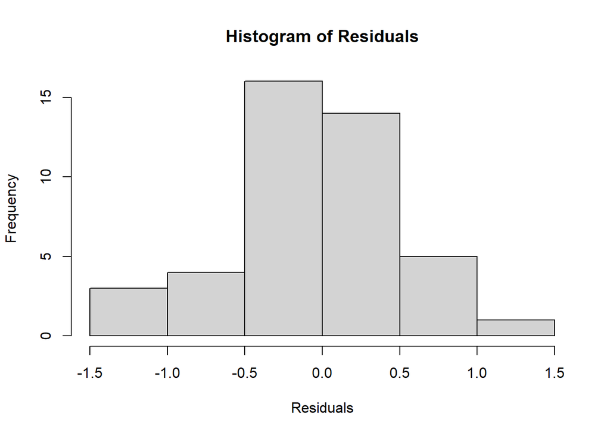

```r
# Histogram of residuals
hist(residuals(model), main = "Histogram of Residuals", xlab = "Residuals")
```

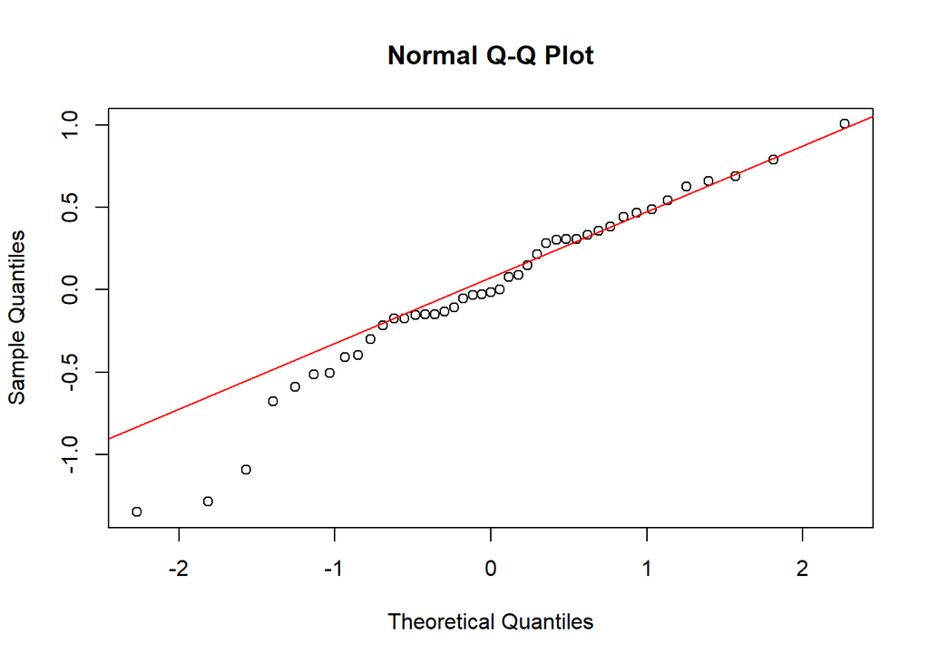

```r
# Q-Q plot
qqnorm(residuals(model))
qqline(residuals(model), col = "red")
```

```r
#Checking for influential outliers

cooks_dist <- cooks.distance(model)

influential <- which(cooks_dist > 1)
print(influential)
```

```
## named integer(0)
```

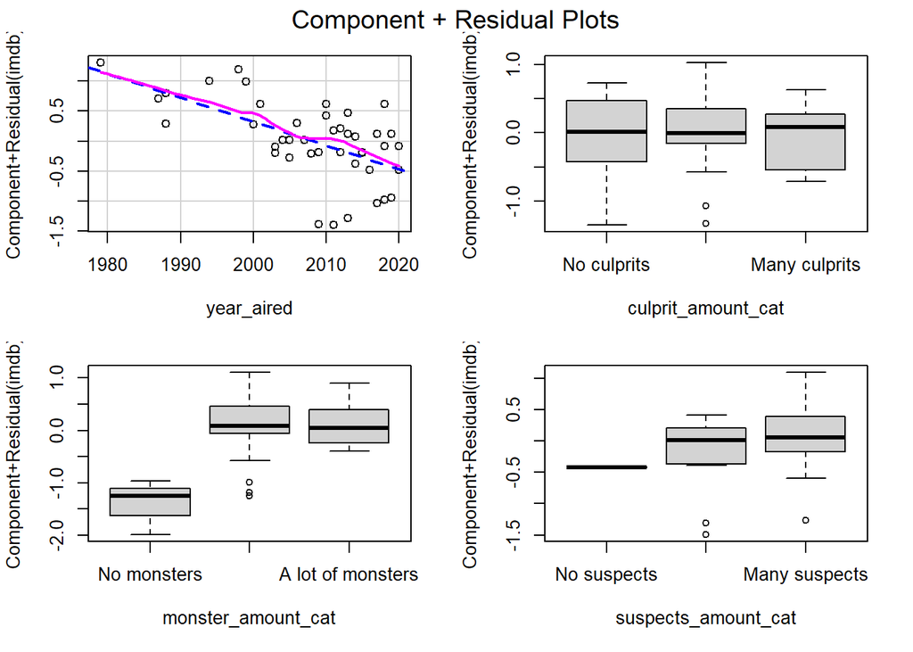

```r
#The assumption of linearity is satisfied for date aired and monsters
car::crPlots(model)
```

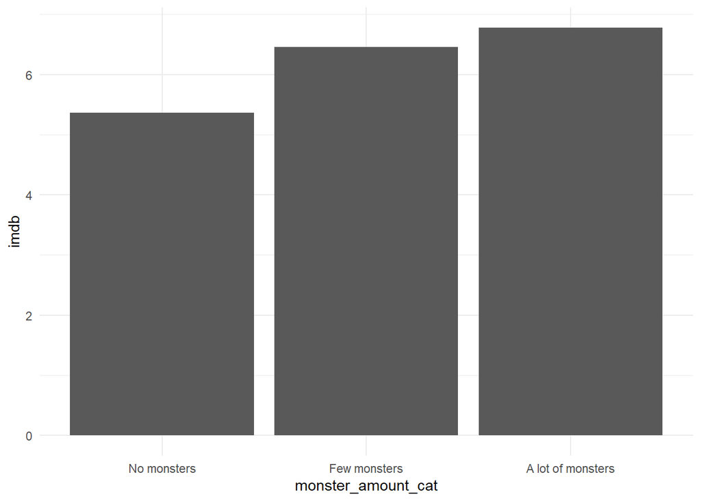

```r
ggplot(scoobydoo_filtered, aes(x = monster_amount_cat, y = imdb)) +
  stat_summary(fun = mean, geom = "bar") +
  theme_minimal()
```

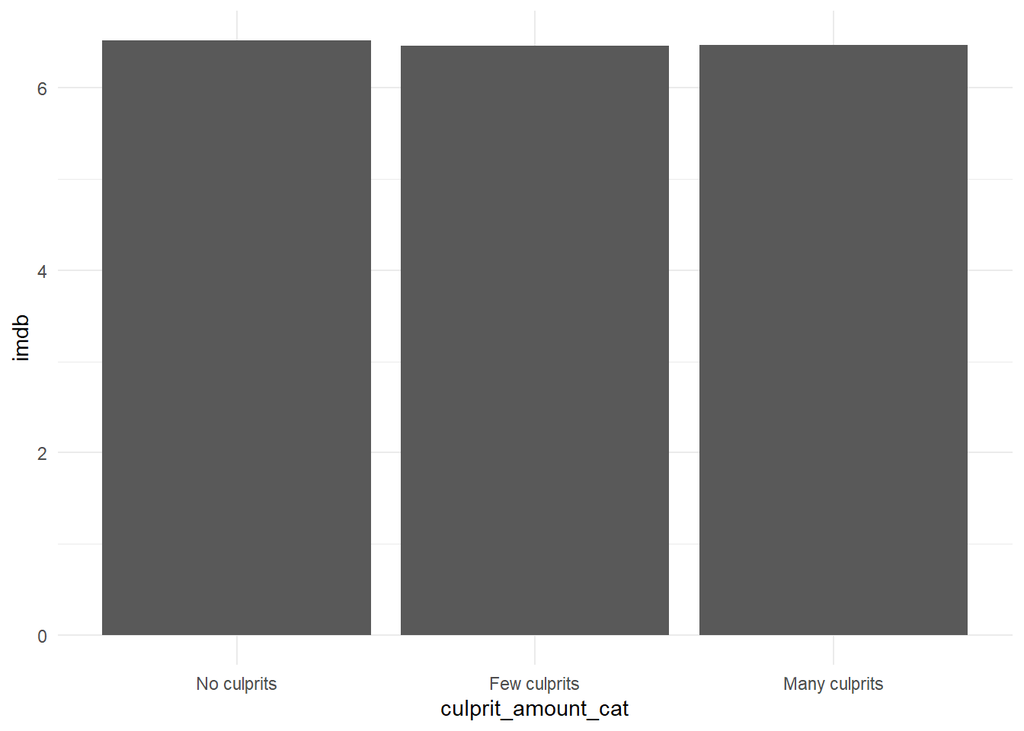

```r
#It seems that there is no significant relationship between imdb and suspects or culprits as predictors.

ggplot(scoobydoo_filtered, aes(x = culprit_amount_cat, y = imdb)) +
  stat_summary(fun = mean, geom = "bar") +
  theme_minimal()
```